# Python数据分析基础

## Python数据分析基础

### 目录：

#### 第1部分 Python快速上手

- 判断
- 循环
- 容器
- 列表生成式
- 生成器
- 异常处理

#### 第2部分 Numpy基础

- Numpy简介
- 创建Numpy数组(ndarray)
- Numpy数组索引与切片
- Numpy的统计计算方法
- 广播(Broadcasting)简介

#### 第3部分 Pandas入门

- pandas简介
- pandas数据结构
- 数据分析项目案例

#### 第1部分 Python快速上手

学习一门编程语言主要就是学如何做判断、如何做循环，有哪些基本的数据结构，然后就是关于异常处理之类的，下面我们来简单的看一下。

#### 1、判断语句

- if–elif–else

```python
pzx = 1
if pzx > 0:
    print('yes')
elif pzx < 0:
    print('none')
else:
    print('no')
```

```
yes
```

#### 2、循环语句

- for循环、while循环

```python
languages = ["C", "C++", "Python"]
for x in languages:
    print (x)
print('')
i = 0
while i < len(languages):
    print (languages[i])
    i += 1
```

```
C
C++
Python

C
C++
Python
```

#### 3、容器

- Python容器：包括列表(list)、元组(tuple)、字典(dict)与集合(set)
- list容器：可以同时存放任意类型数据，可变。

```python
# 初始化列表
li = [1, 2, 3, 'abc', 4.5, [2, 3, 4], {1:'one'}]
```

- 对于任何容器，都可以用len()函数去获取容器的长度

```python
# 获取长度
len(li)
```

```
7
```

- 对于python索引，其增加了一个负数的索引，负数的索引就是从最后一个元素开始数，-1就代表最后一个元素

```python
# 根据索引读写
print(li[0])
print(li[3])
print(li[-1])
```

```
1
abc
{1: 'one'}
```

- 容器的切片，在numpy和pandas的中也会大量遇到切片的场景，切片就是获取容器中的一段元素

```python
li = [0, 1, 2, 3, 4, 5, 6, 7, 8, 9, 10]

# 切片
print(li[2:5])  # 2 <= idx < 5
print(li[:4])
print(li[5:])
print(li[0:6:2])
print(li[-1:3:-1])
```

```
[2, 3, 4]
[0, 1, 2, 3]
[5, 6, 7, 8, 9, 10]
[0, 2, 4]
[10, 9, 8, 7, 6, 5, 4]
```

- 如何添加元素：append与extend的区别

```python
# 添加元素
li = [1, 2, 3]
li.append('a')
li.append('b')
print(li)
li.append([4, 5, 6])
print(li)
li = [1, 2, 3]
li.extend([4, 5, 6])
print(li)
```

```
[1, 2, 3, 'a', 'b']
[1, 2, 3, 'a', 'b', [4, 5, 6]]
[1, 2, 3, 4, 5, 6]
```

- 删除元素的方法：pop()、remove()、del

```python
# 删除元素
li = [1, 2, 3, 4, 5]
li.pop()
li.remove(2)
print(li)
del(li[0])
print(li)
```

```
[1, 3, 4]
[3, 4]
```

- 判断元素是否存在：in、not in关键字

```python
# 判断元素是否存在
li = [1, 2, 3, 4, 5]
print(1 in li)
print(6 not in li)
```

```
True
True
```

- 判断list为空：在Python中，False、0、''、[]、{}、()都可以视为假，如下两种方法都可以判断list是否为空

```python
# 列表是否为空
li = []
if len(li):
    print('Not empty')
else:
    print('Empty')
print('')
if li:
    print('Not empty')
else:
    print('Empty')
```

```
Empty

Empty
```

```python
# 遍历
li = [1, 2, 3]
for i in li:
    print(i)
print('')
for i in range(len(li)):
    print(li[i])
```

```
1
2
3

1
2
3
```

- Python的元组与列表类似，不同之处在于元组的元素不能修改。
- 元组使用小括号，列表使用方括号。

```python
# 初始化元组（tuple）
tuples = (1, 2, 3, 'abc', 4.5, [2, 3, 4], {1:'one'})
```

- 字典容器：一种可变容器模型，且可存储任意类型对象
- 键必须是唯一的，如果重复的话最后的一个键值对会替换前面的，值不需要唯一
- 值可以取任何数据类型，但键必须是不可变类型的，如字符串，数字或元组。

```python
# 初始化
d = {'a':1, 2:'b', 'c':[3,4], (2,3):3.14,}
print(d)
```

```
{'a': 1, 2: 'b', 'c': [3, 4], (2, 3): 3.14}
```

```python
# 获取长度
print(len(d))
```

```
4
```

```python
# 根据key读写
print(d['a'])
print(d[2])
```

```
1
b
```

```python
# 添加元素
d['e'] = 5
d[6] = 'f'
print(d)
```

```
{'a': 1, 2: 'b', 'c': [3, 4], (2, 3): 3.14, 'e': 5, 6: 'f'}
```

```python
# 删除元素
d = {'a':1, 2:'b', 'c':3, 4:'d'}
del(d['a'])
del(d[2])
print(d)
```

```
{'c': 3, 4: 'd'}
```

- 字典遍历常用的方法有两种：按key遍历和按字典项遍历

```python
# 遍历
d = {'a':1, 2:'b', 'c':3}
for k in d.keys():
    print(str(k) + ': ' + str(d[k]))
print('')
for k, v in d.items():
    print(str(k) + ': ' + str(v))
```

```
a: 1
2: b
c: 3

a: 1
2: b
c: 3
```

- 集合（set）是一个无序不重复元素的序列，主要用来做去重操作

```python
# 初始化
s_1 = set([1, 2, 3, 4, 5])
s_2 = set([1, 1, 2, 2, 3, 4, 5])
print(s_1)
print(s_2)
```

```
{1, 2, 3, 4, 5}
{1, 2, 3, 4, 5}
```

```python
# 获取长度
print(len(s_1))
print(len(s_2))
```

```
5
5
```

- 集合支持并集、交集、差集操作，对于一些基本的集合操作，可以直接调用集合的函数去实现，非常方便，在运算符级别就支持。

```python
# 集合操作
s_a = set([1, 2, 3, 4, 5])
s_b = set([4, 5, 6, 7, 8])
# 并集
print(s_a | s_b)
print(s_a.union(s_b))
# 交集
print(s_a & s_b)
print(s_a.intersection(s_b))
# 差集 s_a - (s_a and s_b)
print(s_a - s_b)
print(s_a.difference(s_b))
```

```
{1, 2, 3, 4, 5, 6, 7, 8}
{1, 2, 3, 4, 5, 6, 7, 8}
{4, 5}
{4, 5}
{1, 2, 3}
{1, 2, 3}
```

#### 4、列表生成式

- 运用列表生成式，可以快速生成list，而代码却十分简洁。
- 列表生成式里面实际上是一个生成器，等会儿我们会简单讲下生成器的概念

```python
# 用传统的方法生成一个列表
a = []
for i in range(10):
    a.append(i * 2)
print(a)
```

```
[0, 2, 4, 6, 8, 10, 12, 14, 16, 18]
```

```python
#列表生成式
# 一维数组
print([i * 2 for i in range(10)])
print([i * i for i in range(10)])
print([i * i for i in range(10) if (i % 3) == 0])
print([(x, y) for x in range(3) for y in range(3)])
```

```
[0, 2, 4, 6, 8, 10, 12, 14, 16, 18]
[0, 1, 4, 9, 16, 25, 36, 49, 64, 81]
[0, 9, 36, 81]
[(0, 0), (0, 1), (0, 2), (1, 0), (1, 1), (1, 2), (2, 0), (2, 1), (2, 2)]
```

#### 5、生成器

- 如果通过列表生成式创建一个包含100万个元素的列表，不仅占用很大的存储空间，如果我们仅仅需要访问前面几个元素，那后面绝大多数元素占用的空间都白白浪费了
- 所以，如果列表元素可以按照某种算法推算出来，那我们是否可以在循环的过程中不断推算出后续的元素呢？这样就不必创建完整的list，从而节省大量的空间。
- 在Python中，这种一边循环一边计算的机制，称为生成器：generator

```python
# 创建生成器的简单方法
sx = (x for x in range(5))
print(type(sx))

# 列表生成式里面实际上就是一个生成器，只不过加上一个 [ ] 把生成器强制转换成了list
lx = [x for x in range(5)]
print(type(lx))
```

```
<class 'generator'>
<class 'list'>
```

- 我们可以用for循环来取出生成器中的元素，因为generator也是可迭代对象

```python
for i in sx:
    print(i)
```

```
0
1
2
3
4
```

#### 6、异常处理

- 当我们认为某些代码可能会出错时，就可以用try来运行这段代码，如果执行出错，则后续代码不会继续执行，而是直接跳转至错误处理代码，即except语句块，执行完except后，如果有finally语句块，则执行finally语句块，至此，执行完毕。

```python
try:
    print('try...')
    r = 10 / 0
    print('result:', r)
except Exception as e:
    print('Error Occur:', e)
finally:
    print('finally...')
```

```
try...
Error Occur: division by zero
finally...
```

### 第2部分 Numpy基础

#### 1、Numpy简介

- Numpy是Python语言的一个library
- Numpy主要支持矩阵操作和运算
- Numpy非常高效，core代码由C语言写成
- 我们第3部分要讲的pandas也是基于Numpy构建的一个library
- 现在比较流行的机器学习框架（例如Tensorflow/PyTorch等等），语法都与Numpy比较接近

#### 2、创建Numpy数组(ndarray)

- ndarray：N dimension array，我们可以当做是对高维数组的操作，高维数组还有一个名字叫做Tensor，目前最火的TensorFlow中的tensor其实就是N dimension array，只是换了一个比较高级的名字

```python
import numpy as np

# 使用普通一维数组生成NumPy一维数组
data = [6, 7.5, 8, 0, 1]
arr = np.array(data)
print(arr)
print(arr.dtype) # 类型
```

```
[ 6.   7.5  8.   0.   1. ]
float64
```

```python
# 使用普通二维数组生成NumPy二维数组
data = [[1, 2, 3, 4], [5, 6, 7, 8]]
arr = np.array(data)
print(arr)
print(arr.shape) # 维度
```

```
[[1 2 3 4]
 [5 6 7 8]]
(2, 4)
```

```python
# 使用zeros
print(np.zeros(10)) # 生成包含10个0的一维数组
print('')
print(np.zeros((3, 6))) # 生成 3*6 的二维数组
```

```
[ 0.  0.  0.  0.  0.  0.  0.  0.  0.  0.]

[[ 0.  0.  0.  0.  0.  0.]
 [ 0.  0.  0.  0.  0.  0.]
 [ 0.  0.  0.  0.  0.  0.]]
```

#### 3、Numpy数组索引与切片

```python
# 通过索引访问二维数组某一行或某个元素
arr = np.array([[1, 2, 3], [4, 5, 6], [7, 8, 9]])
print(arr[2])
print(arr[0][2])
print(arr[0, 2]) # 普通Python数组不能用，只有numpy的数组能用。
```

```
[7 8 9]
3
3
```

- numpy可以对二维数组做索引和切片，而python中的list无法做到

```python
# 使用切片访问和操作数组
arr = np.array([[1, 2, 3], [4, 5, 6], [7, 8, 9]])
print(arr[:2]) # 打印第1、2行
print('-----------------------')
print(arr[:2, 1:]) # 打印第1、2行，第2、3列
print('-----------------------')
arr[:2, 1:] = 0 # 第1、2行，第2、3列的元素设置为0，和list切片不同，numpy切片是引用优先
print(arr)
```

```
[[1 2 3]
 [4 5 6]]
-----------------------
[[2 3]
 [5 6]]
-----------------------
[[1 0 0]
 [4 0 0]
 [7 8 9]]
```

```python
# python的list无法做二维数组的索引和切片
li = [[1, 2, 3], [4, 5, 6], [7, 8, 9]]
print(li[:2, 1:])
```

```
---------------------------------------------------------------------------
TypeError                                 Traceback (most recent call last)
<ipython-input-32-7dc15bbb9d95> in <module>()
      1 # python的list无法做二维数组的索引和切片
      2 li = [[1, 2, 3], [4, 5, 6], [7, 8, 9]]
----> 3 print(li[:2, 1:])

TypeError: list indices must be integers or slices, not tuple
```

#### 4、Numpy的统计计算方法

- numpy内置了许多计算方法，其中最重要的统计方法有sum、mean、max，axis=1计算的是行的和，axis=0计算的是列的和

```python
print(arr)
print(arr.sum(axis=1))
print(arr.sum(axis=0))
```

```
[[1 0 0]
 [4 0 0]
 [7 8 9]]
[ 1  4 24]
[12  8  9]
```

#### 5、广播(Broadcasting)简介

- Numpy运算的时候要求输入的数组shape是一致的，当数组的shape不相等时，则会使用广播机制，调整数组使得shape一样，满足一定规则，则可以运算，否则就出错。
- 在Python中，广播不会做大量的数据复制并且通常使计算更加高效。TensorFlow中的广播机制也是继承自numpy的广播功能。
- 一定要注意，执行广播的前提在于，两个ndarray执行的是element-wise（按位加、减、乘、除）的运算，而不是矩阵乘法的运算，矩阵乘法运算时需要维度之间严格匹配。
- 广播规则如下：
  - 如果两个数组的后缘维度(即：从末尾开始算起的维度)的轴长相符或其中一方的长度为1，则认为它们是广播兼容的，广播会在缺失和(或)长度为1的轴上进行.
- 上面的原则很重要，是广播的指导思想，下面我们来看一个具体的例子。

```python
arr1 = np.array([[0],[1],[2],[3]]) # 创建一个4行1列的二维数组
arr1.shape
```

```
(4, 1)
```

```python
arr2 = np.array([1,2,3]) # 创建一个长度为3的一维数组
arr2.shape
```

```
(3,)
```

```python
arr1 + arr2
```

```
array([[1, 2, 3],
       [2, 3, 4],
       [3, 4, 5],
       [4, 5, 6]])
```

根据广播原则：arr1的shape为(4,1)，后缘维度为1，arr2的shape为(3,),所以会同时在两个轴发生广播，arr1的shape变成(4,3)，arr2的shape也变成(4,3),所以结果也为(4,3)。其实代码中发生了下图描述的事情：

[figure not shown]

### 第3部分 Pandas入门

#### 1、Pandas简介

- python数据分析library
- 基于numpy (对ndarray的操作)
- 有一种用python做Excel/SQL的感觉，因为提供了大量能使我们快速便捷地处理数据的函数和方法。

#### 2、pandas数据结构

- pandas主要使用的是两个数据结构Series和Dataframe
- Series可以被认为是一维数组，Series与一维数组最主要的区别是Series可以指定索引序列
- DataFrame是将数个Series按列合并而成的二维数据结构，每一列单独取出来是一个Series，他的每一行有索引，每一列也有索引

```python
from pandas import Series, DataFrame
```

```python
# 指定Series的index
obj2 = Series([4, 7, -5, 3], index = ['d', 'b', 'a', 'c'])
obj2
```

```
d    4
b    7
a   -5
c    3
dtype: int64
```

```python
# 用字典生成DataFrame，key为列的名字。
d = {'one' : Series([1.,2.,3.] , index=['a' , 'b' , 'c']),
     'two' : Series([1.,2.,3.,4.] , index=['a' , 'b' , 'c' , 'd'])}
df = DataFrame(d)
df
```

|  | one | two |
| --- | --- | --- |
| a | 1.0 | 1.0 |
| b | 2.0 | 2.0 |
| c | 3.0 | 3.0 |
| d | NaN | 4.0 |

#### 3、数据分析项目案例

- 本案例简单介绍下我们实际应用的时候如何读取数据，如何做表格拼接、数据探索、分组与聚合等等操作

```python
import pandas as pd
%matplotlib inline
```

- 读入数据：可以用read_csv()方法读取student-info.csv和student-score.csv两张表的数据

```python
df_info=pd.read_csv('student-info.csv',sep=';')
df_info.head()
```

|  | ID | school | sex | age | address | famsize | Pstatus | Medu | Fedu | Mjob | ... | higher | internet | romantic | famrel | freetime | goout | Dalc | Walc | health | absences |
| --- | --- | --- | --- | --- | --- | --- | --- | --- | --- | --- | --- | --- | --- | --- | --- | --- | --- | --- | --- | --- | --- |
| 0 | 0 | GP | F | 18 | U | GT3 | A | 4 | 4 | at_home | ... | yes | no | no | 4 | 3 | 4 | 1 | 1 | 3 | 6 |
| 1 | 1 | GP | F | 17 | U | GT3 | T | 1 | 1 | at_home | ... | yes | yes | no | 5 | 3 | 3 | 1 | 1 | 3 | 4 |
| 2 | 2 | GP | F | 15 | U | LE3 | T | 1 | 1 | at_home | ... | yes | yes | no | 4 | 3 | 2 | 2 | 3 | 3 | 10 |
| 3 | 3 | GP | F | 15 | U | GT3 | T | 4 | 2 | health | ... | yes | yes | yes | 3 | 2 | 2 | 1 | 1 | 5 | 2 |
| 4 | 4 | GP | F | 16 | U | GT3 | T | 3 | 3 | other | ... | yes | no | no | 4 | 3 | 2 | 1 | 2 | 5 | 4 |

5 rows × 31 columns

```python
df_score=pd.read_csv('student-score.csv',sep=';')
df_score.head()
```

|  | ID | G1 | G2 | G3 |
| --- | --- | --- | --- | --- |
| 0 | 0 | 5 | 6 | 6 |
| 1 | 1 | 5 | 5 | 6 |
| 2 | 2 | 7 | 8 | 10 |
| 3 | 3 | 15 | 14 | 15 |
| 4 | 4 | 6 | 10 | 10 |

- 把两张表按照学生ID对齐拼接起来，结果存在一个新DataFrame "df" 中

```python
df=pd.merge(df_info, df_score, how = 'inner', on = 'ID')
df.head()
```

|  | ID | school | sex | age | address | famsize | Pstatus | Medu | Fedu | Mjob | ... | famrel | freetime | goout | Dalc | Walc | health | absences | G1 | G2 | G3 |
| --- | --- | --- | --- | --- | --- | --- | --- | --- | --- | --- | --- | --- | --- | --- | --- | --- | --- | --- | --- | --- | --- |
| 0 | 0 | GP | F | 18 | U | GT3 | A | 4 | 4 | at_home | ... | 4 | 3 | 4 | 1 | 1 | 3 | 6 | 5 | 6 | 6 |
| 1 | 1 | GP | F | 17 | U | GT3 | T | 1 | 1 | at_home | ... | 5 | 3 | 3 | 1 | 1 | 3 | 4 | 5 | 5 | 6 |
| 2 | 2 | GP | F | 15 | U | LE3 | T | 1 | 1 | at_home | ... | 4 | 3 | 2 | 2 | 3 | 3 | 10 | 7 | 8 | 10 |
| 3 | 3 | GP | F | 15 | U | GT3 | T | 4 | 2 | health | ... | 3 | 2 | 2 | 1 | 1 | 5 | 2 | 15 | 14 | 15 |
| 4 | 4 | GP | F | 16 | U | GT3 | T | 3 | 3 | other | ... | 4 | 3 | 2 | 1 | 2 | 5 | 4 | 6 | 10 | 10 |

5 rows × 34 columns

- 先做一下数据探索，对数据有个总体的了解

```python
df.shape
```

```
(395, 34)
```

```python
df.describe()
```

|  | ID | age | Medu | Fedu | traveltime | studytime | failures | famrel | freetime | goout | Dalc | Walc | health | absences | G1 | G2 | G3 |
| --- | --- | --- | --- | --- | --- | --- | --- | --- | --- | --- | --- | --- | --- | --- | --- | --- | --- |
| count | 395.000000 | 395.000000 | 395.000000 | 395.000000 | 395.000000 | 395.000000 | 395.000000 | 395.000000 | 395.000000 | 395.000000 | 395.000000 | 395.000000 | 395.000000 | 395.000000 | 395.000000 | 395.000000 | 395.000000 |
| mean | 197.000000 | 16.696203 | 2.749367 | 2.521519 | 1.448101 | 2.035443 | 0.334177 | 3.944304 | 3.235443 | 3.108861 | 1.481013 | 2.291139 | 3.554430 | 5.708861 | 10.908861 | 10.713924 | 10.415190 |
| std | 114.170924 | 1.276043 | 1.094735 | 1.088201 | 0.697505 | 0.839240 | 0.743651 | 0.896659 | 0.998862 | 1.113278 | 0.890741 | 1.287897 | 1.390303 | 8.003096 | 3.319195 | 3.761505 | 4.581443 |
| min | 0.000000 | 15.000000 | 0.000000 | 0.000000 | 1.000000 | 1.000000 | 0.000000 | 1.000000 | 1.000000 | 1.000000 | 1.000000 | 1.000000 | 1.000000 | 0.000000 | 3.000000 | 0.000000 | 0.000000 |
| 25% | 98.500000 | 16.000000 | 2.000000 | 2.000000 | 1.000000 | 1.000000 | 0.000000 | 4.000000 | 3.000000 | 2.000000 | 1.000000 | 1.000000 | 3.000000 | 0.000000 | 8.000000 | 9.000000 | 8.000000 |
| 50% | 197.000000 | 17.000000 | 3.000000 | 2.000000 | 1.000000 | 2.000000 | 0.000000 | 4.000000 | 3.000000 | 3.000000 | 1.000000 | 2.000000 | 4.000000 | 4.000000 | 11.000000 | 11.000000 | 11.000000 |
| 75% | 295.500000 | 18.000000 | 4.000000 | 3.000000 | 2.000000 | 2.000000 | 0.000000 | 5.000000 | 4.000000 | 4.000000 | 2.000000 | 3.000000 | 5.000000 | 8.000000 | 13.000000 | 13.000000 | 14.000000 |
| max | 394.000000 | 22.000000 | 4.000000 | 4.000000 | 4.000000 | 4.000000 | 3.000000 | 5.000000 | 5.000000 | 5.000000 | 5.000000 | 5.000000 | 5.000000 | 75.000000 | 19.000000 | 19.000000 | 20.000000 |

```python
df.info()
```

```
<class 'pandas.core.frame.DataFrame'>
Int64Index: 395 entries, 0 to 394
Data columns (total 34 columns):
ID            395 non-null int64
school        395 non-null object
sex           395 non-null object
age           395 non-null int64
address       395 non-null object
famsize       395 non-null object
Pstatus       395 non-null object
Medu          395 non-null int64
Fedu          395 non-null int64
Mjob          395 non-null object
Fjob          395 non-null object
reason        395 non-null object
guardian      395 non-null object
traveltime    395 non-null int64
studytime     395 non-null int64
failures      395 non-null int64
schoolsup     395 non-null object
famsup        395 non-null object
paid          395 non-null object
activities    395 non-null object
nursery       395 non-null object
higher        395 non-null object
internet      395 non-null object
romantic      395 non-null object
famrel        395 non-null int64
freetime      395 non-null int64
goout         395 non-null int64
Dalc          395 non-null int64
Walc          395 non-null int64
health        395 non-null int64
absences      395 non-null int64
G1            395 non-null int64
G2            395 non-null int64
G3            395 non-null int64
dtypes: int64(17), object(17)
memory usage: 108.0+ KB
```

- 统计男生的平均分和女生的三门科目的平均分(G1, G2, G3)，可以使用groupby和aggregate来操作

```python
group_by_sex = df.groupby('sex') # groupby实际上还没有进行任何计算，只是含有一些有关'sex'分组的中间数据而已
group_by_sex.agg({"G1": np.mean, "G2": np.mean, "G3": np.mean})
```

| sex | G1 | G2 | G3 |
| --- | --- | --- | --- |
| F | 10.620192 | 10.389423 | 9.966346 |
| M | 11.229947 | 11.074866 | 10.914439 |

- 统计不同年龄的学生三门科目(G1, G2, G3)的平均分，并作出柱状图展示

```python
group_by_age = df.groupby('age')
age_mean=group_by_age.agg({"G1": np.mean, "G2": np.mean, "G3": np.mean})
age_mean
```

| age | G1 | G2 | G3 |
| --- | --- | --- | --- |
| 15 | 11.231707 | 11.365854 | 11.256098 |
| 16 | 10.942308 | 11.182692 | 11.028846 |
| 17 | 10.897959 | 10.479592 | 10.275510 |
| 18 | 10.719512 | 10.134146 | 9.548780 |
| 19 | 10.250000 | 9.250000 | 8.208333 |
| 20 | 13.666667 | 13.666667 | 14.000000 |
| 21 | 10.000000 | 8.000000 | 7.000000 |
| 22 | 6.000000 | 8.000000 | 8.000000 |

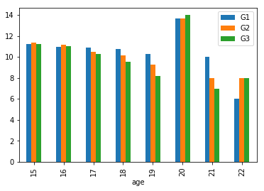

```python
age_mean.plot(kind='bar')
```

```python
df['all_score'] = df.loc[:, ['G1', 'G2', 'G3']].apply(lambda x: x.sum(), axis = 1)
df.nlargest(columns='all_score', n=10) # nlargest()能一次看到最大的几行，而且不需要手动排序
```

|  | ID | school | sex | age | address | famsize | Pstatus | Medu | Fedu | Mjob | ... | freetime | goout | Dalc | Walc | health | absences | G1 | G2 | G3 | all_score |
| --- | --- | --- | --- | --- | --- | --- | --- | --- | --- | --- | --- | --- | --- | --- | --- | --- | --- | --- | --- | --- | --- |
| 47 | 47 | GP | M | 16 | U | GT3 | T | 4 | 3 | health | ... | 2 | 2 | 1 | 1 | 2 | 4 | 19 | 19 | 20 | 58 |
| 110 | 110 | GP | M | 15 | U | LE3 | A | 4 | 4 | teacher | ... | 5 | 3 | 1 | 1 | 4 | 6 | 18 | 19 | 19 | 56 |
| 113 | 113 | GP | M | 15 | U | LE3 | T | 4 | 2 | teacher | ... | 5 | 2 | 1 | 1 | 3 | 10 | 18 | 19 | 19 | 56 |
| 374 | 374 | MS | F | 18 | R | LE3 | T | 4 | 4 | other | ... | 4 | 4 | 1 | 1 | 1 | 0 | 19 | 18 | 19 | 56 |
| 42 | 42 | GP | M | 15 | U | GT3 | T | 4 | 4 | services | ... | 3 | 3 | 1 | 1 | 5 | 2 | 19 | 18 | 18 | 55 |
| 286 | 286 | GP | F | 18 | U | GT3 | T | 2 | 2 | at_home | ... | 3 | 3 | 1 | 2 | 2 | 5 | 18 | 18 | 19 | 55 |
| 129 | 129 | GP | M | 16 | R | GT3 | T | 4 | 4 | teacher | ... | 5 | 5 | 2 | 5 | 4 | 8 | 18 | 18 | 18 | 54 |
| 198 | 198 | GP | F | 17 | U | GT3 | T | 4 | 4 | services | ... | 2 | 4 | 2 | 3 | 2 | 24 | 18 | 18 | 18 | 54 |
| 245 | 245 | GP | M | 16 | U | GT3 | T | 2 | 1 | other | ... | 3 | 3 | 1 | 1 | 4 | 6 | 18 | 18 | 18 | 54 |
| 293 | 293 | GP | F | 17 | R | LE3 | T | 3 | 1 | services | ... | 1 | 2 | 1 | 1 | 3 | 6 | 18 | 18 | 18 | 54 |

10 rows × 35 columns